# Los Angeles airport passenger prediction with Box Jenkins

### Create dummies

We split all outliers into 4 groups to create 4 dummies

```r
#first dummy
Lax_data$dum_1 <- 0
Lax_data$dum_1[out1] <- 1

length(Lax_data$dum_1)
```

```
## [1] 159
```

```r
#second dummy
Lax_data$dum_2 <- 0
Lax_data$dum_2[out2] <- 1

#third dummy
Lax_data$dum_3 <- 0
Lax_data$dum_3[out3] <- 1

#fourth dummy
Lax_data$dum_4 <- 0
Lax_data$dum_4[out4] <- 1
```

### Run our model

For notice, in order to incorporate multiple dummies variable, we had to create a cbind matrix into xreg parameters.

```r
mod2 <- arima(ltraf, c(0, 1, 1),seasonal = list(order = c(0, 1, 1), period = 12),
              method='ML',xreg=cbind(unlist(Lax_data$dum_1),
                                     unlist(Lax_data$dum_2),
                                     unlist(Lax_data$dum_3),
                                     unlist(Lax_data$dum_4)
                                     ))

ncol(cbind(unlist(Lax_data$dum_1), unlist(Lax_data$dum_2), unlist(Lax_data$dum_3), unlist(Lax_data$dum_4)))
```

```
## [1] 4
```

```r
mod2
```

```
##
## Call:
## arima(x = ltraf, order = c(0, 1, 1), seasonal = list(order = c(0, 1, 1), period = 12),
##     xreg = cbind(unlist(Lax_data$dum_1), unlist(Lax_data$dum_2), unlist(Lax_data$dum_3),
##         unlist(Lax_data$dum_4)), method = "ML")
##
## Coefficients:
##           ma1     sma1    xreg1   xreg2   xreg3    xreg4
##       -0.3622  -0.6969  -0.0318  0.0445  0.0643  -0.0465
## s.e.   0.0716   0.0792   0.0148  0.0145  0.0154   0.0154
##
## sigma^2 estimated as 0.0003598:  log likelihood = 367.66,  aic = -723.31
```

xreg : additional variable I want to take into account

By adding xreg, we will be able to control the misfit at the years written below. We have even gain small AIC !

Let’s re-run our residuals analysis in this model.

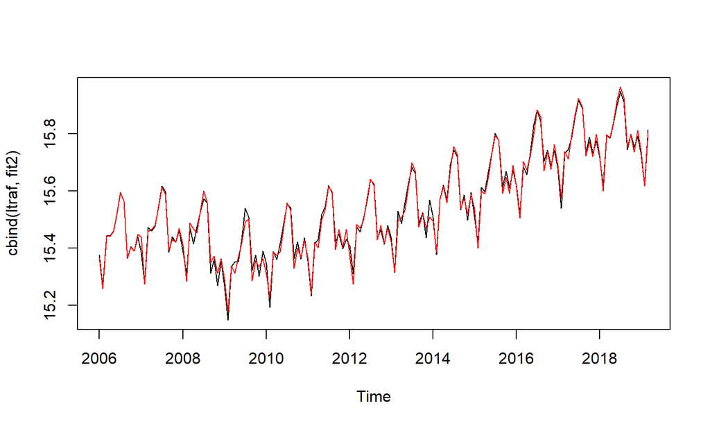

```r
fit2 <- fitted(mod2)
plot.ts(cbind(ltraf,fit2),plot.type='single',col=c('black','red'))
```